# OurLogo

- Home
- About
- Training materials

# Production efficiency and the role of collective action among irrigated rice farms in Northern Thailand.

Christopher Llones

Last edited: 03 June 2021

# 1 Descriptive statistics

### Input and output variables

```r
data %>%
   select(prod, seed.q, fert.q, fl.labor.hr, hl.labor.hr,
          pestq.dum, soil_qual, topog, area) %>%
   mutate(prod = prod / area,
          seed.q = seed.q / area,
          fert.q = fert.q / area,
          fl.labor.hr = fl.labor.hr / area,
          hl.labor.hr = fl.labor.hr / area) %>%
   rename('Production (kg)' = prod,
          'Seed (kg)' = seed.q,
          'Fertilizer (kg)' = fert.q,
          'Family labor (hr)' = fl.labor.hr,
          'Hired labor (hr)' = hl.labor.hr,
          'Pesticide (1=yes; 0=no)' = pestq.dum,
          'Good soil (1=yes; 0=no)'= soil_qual,
          'Upland(1=yes; 0=no)' = topog,
          Area = area) %>%
   select_all() %>%
   describe() %>%
   kable(digits = 2,
         caption = "Descriptive stastics of variables
         used in SFPF estimation") %>%
   kable_classic_2() %>%
   kable_styling(full_width = F,
                 bootstrap_options = c("striped", "hover",
                                       "condensed", "responsive"))
```

Descriptive stastics of variables used in SFPF estimation

|  | vars | n | mean | sd | median | trimmed | mad | min | max | range | skew | kurtosis | se |
| --- | --- | --- | --- | --- | --- | --- | --- | --- | --- | --- | --- | --- | --- |
| Production (kg) | 1 | 294 | 740.91 | 160.57 | 725.00 | 736.25 | 160.62 | 285.71 | 1583.33 | 1297.62 | 0.54 | 1.76 | 9.36 |
| Seed (kg) | 2 | 294 | 17.42 | 4.88 | 17.50 | 17.31 | 3.71 | 8.00 | 50.00 | 42.00 | 1.01 | 5.35 | 0.28 |
| Fertilizer (kg) | 3 | 294 | 36.69 | 14.96 | 31.25 | 35.36 | 9.27 | 12.50 | 100.00 | 87.50 | 1.36 | 2.97 | 0.87 |
| Family labor (hr) | 4 | 294 | 77.13 | 56.80 | 63.75 | 68.75 | 43.37 | 4.00 | 288.00 | 284.00 | 1.44 | 2.05 | 3.31 |
| Hired labor (hr) | 5 | 294 | 9.69 | 7.81 | 8.00 | 8.61 | 6.48 | 0.35 | 55.00 | 54.65 | 1.79 | 5.11 | 0.46 |
| Pesticide (1=yes; 0=no) | 6 | 294 | 0.45 | 0.50 | 0.00 | 0.44 | 0.00 | 0.00 | 1.00 | 1.00 | 0.20 | -1.96 | 0.03 |
| Good soil (1=yes; 0=no) | 7 | 294 | 0.89 | 0.31 | 1.00 | 0.99 | 0.00 | 0.00 | 1.00 | 1.00 | -2.56 | 4.55 | 0.02 |
| Upland(1=yes; 0=no) | 8 | 294 | 0.76 | 0.43 | 1.00 | 0.82 | 0.00 | 0.00 | 1.00 | 1.00 | -1.18 | -0.61 | 0.03 |
| Area | 9 | 294 | 10.62 | 6.46 | 10.00 | 10.11 | 7.41 | 1.00 | 32.00 | 31.00 | 0.72 | -0.09 | 0.38 |

### Household characteristics and collective action variables

```r
data %>%
   select(age, hh.mem, educ_primary, educ_secondary, yrs.farming,
          off_farm, input_market, sell_market,
          M55, L41, N75, M54) %>%
   rename(Age = age,
          'Household size (head)' = hh.mem,
          'Primary (1=yes; 0=no)' = educ_primary,
          'Secondary(1=yes; 0=no)' = educ_secondary,
          'Farming experience (years)' = yrs.farming,
          'Off-farm income(1=yes; 0=no)' = off_farm,
          'Distance to input market (km)' = input_market,
          'Distance to market (km)' = sell_market,
          'Maintenance work (1=Never; 7=Always)' = M55,
          'Group meeting (1=Never; 7=Always)' = L41,
          'Conflict resolution (1=Never; 7=Always)' = N75,
          'Policy adherence (1=Never; 7=Always)' = M54
          ) %>%
   select_all() %>%
   describe() %>%
   kable(digits = 2,
         caption = "Descriptive stastics of farmer's
         characteristics and collective action variables") %>%
   kable_classic_2() %>%
   kable_styling(full_width = F,
                 bootstrap_options = c("striped", "hover",
                                       "condensed", "responsive"))
```

Descriptive stastics of farmer’s characteristics and collective action variables

|  | vars | n | mean | sd | median | trimmed | mad | min | max | range | skew | kurtosis | se |
| --- | --- | --- | --- | --- | --- | --- | --- | --- | --- | --- | --- | --- | --- |
| Age | 1 | 294 | 57.88 | 9.77 | 59 | 58.96 | 7.41 | 24.0 | 77 | 53.0 | -1.10 | 1.45 | 0.57 |
| Household size (head) | 2 | 294 | 3.47 | 1.37 | 3 | 3.41 | 1.48 | 1.0 | 9 | 8.0 | 0.65 | 1.31 | 0.08 |
| Primary (1=yes; 0=no) | 3 | 294 | 0.66 | 0.48 | 1 | 0.69 | 0.00 | 0.0 | 1 | 1.0 | -0.66 | -1.58 | 0.03 |
| Secondary(1=yes; 0=no) | 4 | 294 | 0.29 | 0.46 | 0 | 0.24 | 0.00 | 0.0 | 1 | 1.0 | 0.91 | -1.18 | 0.03 |
| Farming experience (years) | 5 | 294 | 30.91 | 14.34 | 30 | 31.48 | 14.83 | 1.0 | 63 | 62.0 | -0.32 | -0.81 | 0.84 |
| Off-farm income(1=yes; 0=no) | 6 | 294 | 0.19 | 0.39 | 0 | 0.11 | 0.00 | 0.0 | 1 | 1.0 | 1.57 | 0.46 | 0.02 |
| Distance to input market (km) | 7 | 294 | 6.59 | 5.78 | 5 | 5.66 | 5.93 | 0.0 | 30 | 30.0 | 1.32 | 1.83 | 0.34 |
| Distance to market (km) | 8 | 294 | 9.65 | 6.58 | 10 | 8.96 | 4.45 | 0.3 | 50 | 49.7 | 1.60 | 4.96 | 0.38 |
| Maintenance work (1=Never; 7=Always) | 9 | 294 | 4.97 | 1.54 | 5 | 5.11 | 1.48 | 1.0 | 7 | 6.0 | -0.66 | 0.13 | 0.09 |
| Group meeting (1=Never; 7=Always) | 10 | 294 | 4.92 | 1.38 | 5 | 5.01 | 1.48 | 1.0 | 7 | 6.0 | -0.67 | 0.75 | 0.08 |
| Conflict resolution (1=Never; 7=Always) | 11 | 294 | 4.39 | 1.74 | 5 | 4.45 | 1.48 | 1.0 | 7 | 6.0 | -0.24 | -0.81 | 0.10 |
| Policy adherence (1=Never; 7=Always) | 12 | 294 | 4.99 | 1.49 | 5 | 5.11 | 1.48 | 1.0 | 7 | 6.0 | -0.70 | 0.37 | 0.09 |

### Collective action correlation

```r
cor_test <- data_scale %>%
   select(maintenance:policy) %>%
   psych::corr.test(method = "spearman")

# correlation coefficient
cor_test$r %>%
   kable(digits = 3,
         caption = "Correlation coefficient") %>%
   kable_classic_2() %>%
   kable_styling(full_width = F,
                 bootstrap_options = c("striped", "hover",
                                       "condensed", "responsive"))
```

Correlation coefficient

|  | maintenance | meeting | conflict | policy |
| --- | --- | --- | --- | --- |
| maintenance | 1.000 | 0.493 | 0.326 | 0.657 |
| meeting | 0.493 | 1.000 | 0.255 | 0.479 |
| conflict | 0.326 | 0.255 | 1.000 | 0.330 |
| policy | 0.657 | 0.479 | 0.330 | 1.000 |

```r
# correlation test standard error
cor_test$se %>%
   kable(digits = 3,
         caption = "Correlation test standard error") %>%
   kable_classic_2() %>%
   kable_styling(full_width = F,
                 bootstrap_options = c("striped", "hover",
                                       "condensed", "responsive"))
```

Correlation test standard error

|  | maintenance | meeting | conflict | policy |
| --- | --- | --- | --- | --- |
| maintenance | 0.000 | 0.051 | 0.055 | 0.044 |
| meeting | 0.051 | 0.000 | 0.057 | 0.051 |
| conflict | 0.055 | 0.057 | 0.000 | 0.055 |
| policy | 0.044 | 0.051 | 0.055 | 0.000 |

# 2 Specifying production function

### Cobb-Douglas production function

The Cobb-Douglas production function was specified using the formula below:

$$\ln y_i = \alpha_0 + \sum_{j=1}^4 \ln \alpha_j X_{ji} + \sum_{m=1}^3 \delta_m D_{mi}$$

where: $Y_i$ represents the total amount of rice produced by the farm $i$; $X_{ji}$ is the set of $j$th input of the $i$th farm; and $D_{mi}$ refers to a vector of control variables of exogenous environmental factor $m$.

```r
# specifying the Cobb-Douglas production funtion
cd_prod <- lm(log(prod) ~ log(seed.q) + log(fert.q) + log(fl.labor.hr)
              + log(hl.labor.hr) + pestq.dum + soil_qual + topog,
              data = data_scale)

# summary results
cd_prod %>% summary()
```

```
Call:
lm(formula = log(prod) ~ log(seed.q) + log(fert.q) + log(fl.labor.hr) +
    log(hl.labor.hr) + pestq.dum + soil_qual + topog, data = data_scale)

Residuals:
     Min       1Q   Median       3Q      Max
-0.85373 -0.13344  0.00864  0.17567  1.04889

Coefficients:
                 Estimate Std. Error t value Pr(>|t|)
(Intercept)       0.14181    0.05820   2.437   0.0154 *
log(seed.q)       0.43911    0.03936  11.155  < 2e-16 ***
log(fert.q)       0.23032    0.03524   6.535 2.91e-10 ***
log(fl.labor.hr)  0.11794    0.01915   6.157 2.50e-09 ***
log(hl.labor.hr)  0.07628    0.01774   4.300 2.35e-05 ***
pestq.dum        -0.07724    0.03113  -2.482   0.0137 *
soil_qual        -0.03555    0.05150  -0.690   0.4906
topog             0.01426    0.03654   0.390   0.6966
---
Signif. codes:  0 '***' 0.001 '**' 0.01 '*' 0.05 '.' 0.1 ' ' 1

Residual standard error: 0.2638 on 286 degrees of freedom
Multiple R-squared:  0.8681,    Adjusted R-squared:  0.8649
F-statistic:   269 on 7 and 286 DF,  p-value: < 2.2e-16
```

### Cobb-Douglas model diagnostic tests

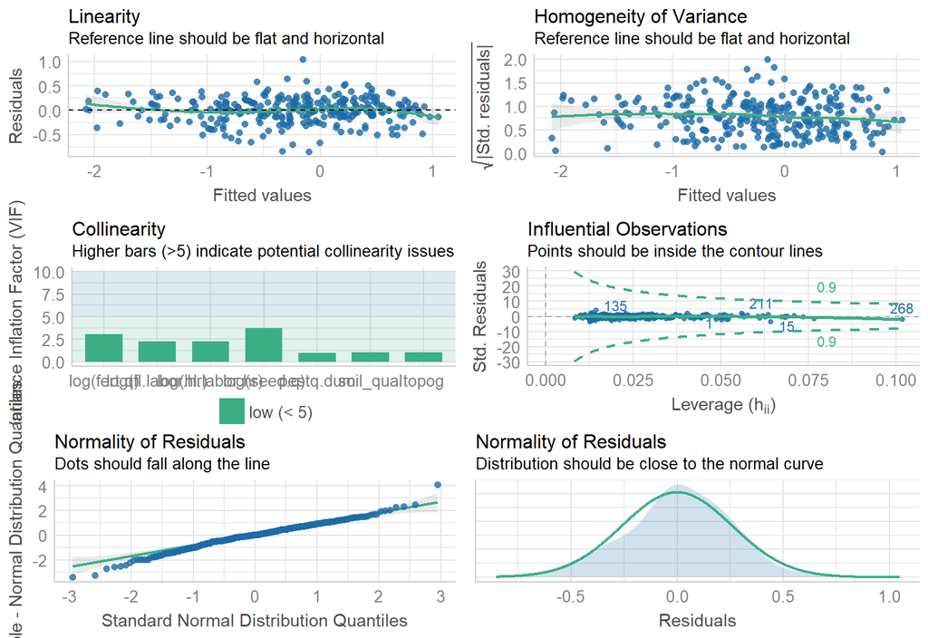

```r
performance::check_model(cd_prod)
```

> The Cobb_Douglas production model passed the diagnostic tests.

### Translog production function

The Translog production function was specified using the formula below:

$$\ln y_i = \alpha_0 + \sum_{j=1}^4 \ln \alpha_j X_{ji} +
\frac{1}{2} \sum_{j=1}^4 \sum_{k=1}^4 \alpha_{jk} \ln X_{ji} \ln X_{ki}
+ \sum_{m=1}^3 \delta_m D_{mi}$$

```r
# specifying the Translog production function
translog_prod <- lm(log(prod) ~ log(seed.q) + log(fert.q) + log(fl.labor.hr)
   + log(hl.labor.hr) + I(0.5 * log(seed.q)^2) + I(0.5 * log(fert.q)^2)
   + I(0.5 * log(fl.labor.hr)^2) + I(0.5 * log(hl.labor.hr)^2)
   + I(log(seed.q) * log(fert.q)) + I(log(seed.q) * log(fl.labor.hr))
   + I(log(seed.q) * log(hl.labor.hr)) + I(log(fert.q) * log(fl.labor.hr))
   + I(log(fert.q) * log(hl.labor.hr)) + I(log(fl.labor.hr) * log(hl.labor.hr)),
   data = data_scale)

# summary results
translog_prod %>% summary()
```

```
Call:
lm(formula = log(prod) ~ log(seed.q) + log(fert.q) + log(fl.labor.hr) +
    log(hl.labor.hr) + I(0.5 * log(seed.q)^2) + I(0.5 * log(fert.q)^2) +
    I(0.5 * log(fl.labor.hr)^2) + I(0.5 * log(hl.labor.hr)^2) +
    I(log(seed.q) * log(fert.q)) + I(log(seed.q) * log(fl.labor.hr)) +
    I(log(seed.q) * log(hl.labor.hr)) + I(log(fert.q) * log(fl.labor.hr)) +
    I(log(fert.q) * log(hl.labor.hr)) + I(log(fl.labor.hr) *
    log(hl.labor.hr)), data = data_scale)

Residuals:
     Min       1Q   Median       3Q      Max
-0.86525 -0.14903  0.01927  0.16519  1.04169

Coefficients:
                                         Estimate Std. Error t value Pr(>|t|)
(Intercept)                             7.925e-02  2.928e-02   2.707  0.00722
log(seed.q)                             4.757e-01  5.401e-02   8.808  < 2e-16
log(fert.q)                             2.080e-01  5.123e-02   4.060 6.37e-05
log(fl.labor.hr)                        1.579e-01  3.076e-02   5.135 5.31e-07
log(hl.labor.hr)                        5.248e-02  2.188e-02   2.399  0.01712
I(0.5 * log(seed.q)^2)                 -7.198e-03  1.325e-01  -0.054  0.95671
I(0.5 * log(fert.q)^2)                  3.663e-05  1.298e-01   0.000  0.99978
I(0.5 * log(fl.labor.hr)^2)             5.355e-02  3.499e-02   1.531  0.12700
I(0.5 * log(hl.labor.hr)^2)            -4.229e-02  2.677e-02  -1.580  0.11521
I(log(seed.q) * log(fert.q))            5.557e-02  1.037e-01   0.536  0.59264
I(log(seed.q) * log(fl.labor.hr))      -6.941e-02  6.241e-02  -1.112  0.26697
I(log(seed.q) * log(hl.labor.hr))       8.307e-02  3.944e-02   2.106  0.03606
I(log(fert.q) * log(fl.labor.hr))      -4.368e-03  4.617e-02  -0.095  0.92469
I(log(fert.q) * log(hl.labor.hr))      -4.641e-02  4.298e-02  -1.080  0.28111
I(log(fl.labor.hr) * log(hl.labor.hr))  1.093e-02  2.364e-02   0.462  0.64409

(Intercept)                            **
log(seed.q)                            ***
log(fert.q)                            ***
log(fl.labor.hr)                       ***
log(hl.labor.hr)                       *
I(0.5 * log(seed.q)^2)
I(0.5 * log(fert.q)^2)
I(0.5 * log(fl.labor.hr)^2)
I(0.5 * log(hl.labor.hr)^2)
I(log(seed.q) * log(fert.q))
I(log(seed.q) * log(fl.labor.hr))
I(log(seed.q) * log(hl.labor.hr))      *
I(log(fert.q) * log(fl.labor.hr))
I(log(fert.q) * log(hl.labor.hr))
I(log(fl.labor.hr) * log(hl.labor.hr))
---
Signif. codes:  0 '***' 0.001 '**' 0.01 '*' 0.05 '.' 0.1 ' ' 1

Residual standard error: 0.2649 on 279 degrees of freedom
Multiple R-squared:  0.8703,    Adjusted R-squared:  0.8638
F-statistic: 133.8 on 14 and 279 DF,  p-value: < 2.2e-16
```

### Translog model diagnostic tests

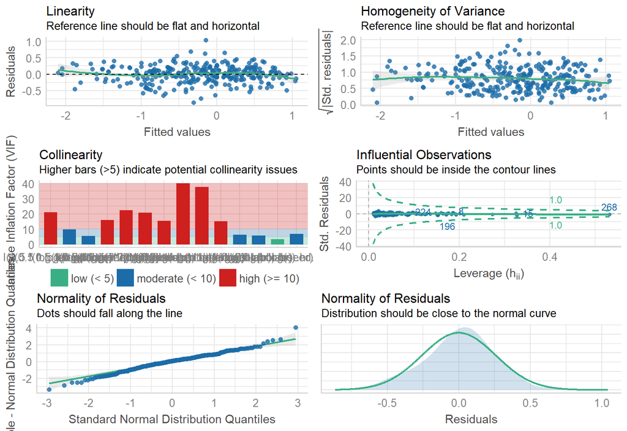

```r
performance::check_model(translog_prod)
```

> As expected, a Translog model shows high collinearity since the added parameter is a product among input used in production. However, other diagnostic tests seems fine.

# 3 Efficiency analysis using SFA

### Cobb-Douglas SF production function

The Cobb-Douglas stochastic frontier production function was specified using the formula below:

$$\ln y_i = \alpha_0 + \sum_{j=1}^4 \ln \alpha_j X_{ji}
+ \sum_{m=1}^3 \delta_m D_{mi}
+ V_i - U_i$$

wherein the variance is parameterized as follows:

$$\sigma^2 = \sigma_v^2 + \sigma_u^2 ;
\gamma = \sigma_u^2 / \sigma^2 (0 \le \gamma \le 1)$$
here $\sigma^2$ is assumed to be an aggregation of random events and technical efficiency. The parameter $\gamma$ explains the impact to technical efficiency on rice production, ranging from 0 to 1. A $\gamma$ near 0 indicates that variation of the real output from frontier output primarily derives from stochastic effects, whereas closer to 1 implies most of the random variations are caused by the effects of inefficiency.

```r
# specifying the Cobb-Douglas stochastic frontier production function
cd_sfa <- sfa(log(prod) ~ log(seed.q) + log(fert.q) + log(fl.labor.hr)
              + log(hl.labor.hr) + pestq.dum
              + soil_qual + topog, data = data_scale)

# summary results
cd_sfa %>% summary(extraPar = T)
```

```
Error Components Frontier (see Battese & Coelli 1992)
Inefficiency decreases the endogenous variable (as in a production function)
The dependent variable is logged
Iterative ML estimation terminated after 12 iterations:
log likelihood values and parameters of two successive iterations
are within the tolerance limit

final maximum likelihood estimates
                   Estimate Std. Error z value  Pr(>|z|)
(Intercept)       0.3541909  0.0707737  5.0046 5.599e-07 ***
log(seed.q)       0.4415840  0.0390862 11.2977 < 2.2e-16 ***
log(fert.q)       0.2276094  0.0344907  6.5992 4.135e-11 ***
log(fl.labor.hr)  0.1171981  0.0184582  6.3494 2.162e-10 ***
log(hl.labor.hr)  0.0749088  0.0176034  4.2554 2.087e-05 ***
pestq.dum        -0.0805165  0.0303054 -2.6568 0.0078877 **
soil_qual        -0.0417675  0.0501828 -0.8323 0.4052360
topog             0.0163797  0.0356664  0.4592 0.6460570
sigmaSq           0.1112966  0.0201049  5.5358 3.098e-08 ***
gamma             0.6180098  0.1401554  4.4095 1.036e-05 ***
sigmaSqU          0.0687824  0.0272265  2.5263 0.0115270 *
sigmaSqV          0.0425142  0.0094836  4.4829 7.363e-06 ***
sigma             0.3336115  0.0301322 11.0716 < 2.2e-16 ***
sigmaU            0.2622640  0.0519067  5.0526 4.358e-07 ***
sigmaV            0.2061898  0.0229973  8.9658 < 2.2e-16 ***
lambdaSq          1.6178680  0.9605179  1.6844 0.0921101 .
lambda            1.2719544  0.3775756  3.3687 0.0007551 ***
varU              0.0249942         NA      NA        NA
sdU               0.1580954         NA      NA        NA
gammaVar          0.3702379         NA      NA        NA
---
Signif. codes:  0 '***' 0.001 '**' 0.01 '*' 0.05 '.' 0.1 ' ' 1
log likelihood value: -19.85304

cross-sectional data
total number of observations = 294

mean efficiency: 0.8213756
```

> The mean technical efficiency is 82% and approximately 61% of the variations in the production function accrues to the effects of inefficiency.

### Translog SF production function

The Translog production function was specified using the formula below:

$$\ln y_i = \alpha_0 + \sum_{j=1}^4 \ln \alpha_j X_{ji} +
\frac{1}{2} \sum_{j=1}^4 \sum_{k=1}^4 \alpha_{jk} \ln X_{ji} \ln X_{ki}
+ \sum_{m=1}^3 \delta_m D_{mi}
+ V_i - U_i$$

wherein the variance is parameterized as follows:

$$\sigma^2 = \sigma_v^2 + \sigma_u^2 ;
\gamma = \sigma_u^2 / \sigma^2 (0 \le \gamma \le 1)$$

```r
# specifying the Cobb-Douglas stochastic frontier production function
translog_sfa <- sfa(log(prod) ~ log(seed.q) + log(fert.q) + log(fl.labor.hr)
   + log(hl.labor.hr) + I(0.5 * log(seed.q)^2) + I(0.5 * log(fert.q)^2)
   + I(0.5 * log(fl.labor.hr)^2) + I(0.5 * log(hl.labor.hr)^2)
   + I(log(seed.q) * log(fert.q)) + I(log(seed.q) * log(fl.labor.hr))
   + I(log(seed.q) * log(hl.labor.hr)) + I(log(fert.q) * log(fl.labor.hr))
   + I(log(fert.q) * log(hl.labor.hr)) + I(log(fl.labor.hr) * log(hl.labor.hr))
   + pestq.dum + soil_qual + topog,
   data = data_scale)

# summary results
translog_sfa %>% summary(extraPar = T)
```

```
Error Components Frontier (see Battese & Coelli 1992)
Inefficiency decreases the endogenous variable (as in a production function)
The dependent variable is logged
Iterative ML estimation terminated after 23 iterations:
cannot find a parameter vector that results in a log-likelihood value
larger than the log-likelihood value obtained in the previous step

final maximum likelihood estimates
                                         Estimate Std. Error z value  Pr(>|z|)
(Intercept)                             0.3477843  0.0816982  4.2569 2.072e-05
log(seed.q)                             0.4672668  0.0514916  9.0746 < 2.2e-16
log(fert.q)                             0.2121640  0.0495531  4.2815 1.856e-05
log(fl.labor.hr)                        0.1518540  0.0294018  5.1648 2.407e-07
log(hl.labor.hr)                        0.0496363  0.0214126  2.3181 0.0204443
I(0.5 * log(seed.q)^2)                 -0.0459688  0.1300713 -0.3534 0.7237794
I(0.5 * log(fert.q)^2)                 -0.0514244  0.1253425 -0.4103 0.6816070
I(0.5 * log(fl.labor.hr)^2)             0.0473460  0.0340031  1.3924 0.1638012
I(0.5 * log(hl.labor.hr)^2)            -0.0477019  0.0262655 -1.8161 0.0693480
I(log(seed.q) * log(fert.q))            0.0809489  0.1011251  0.8005 0.4234313
I(log(seed.q) * log(fl.labor.hr))      -0.0702329  0.0599909 -1.1707 0.2417089
I(log(seed.q) * log(hl.labor.hr))       0.0822963  0.0383046  2.1485 0.0316763
I(log(fert.q) * log(fl.labor.hr))       0.0039202  0.0447609  0.0876 0.9302099
I(log(fert.q) * log(hl.labor.hr))      -0.0349308  0.0408563 -0.8550 0.3925693
I(log(fl.labor.hr) * log(hl.labor.hr))  0.0077172  0.0223657  0.3450 0.7300598
pestq.dum                              -0.0846040  0.0302652 -2.7954 0.0051832
soil_qual                              -0.0376326  0.0519794 -0.7240 0.4690714
topog                                   0.0122920  0.0353747  0.3475 0.7282300
sigmaSq                                 0.1034929  0.0208130  4.9725 6.609e-07
gamma                                   0.5873195  0.1684902  3.4858 0.0004907
sigmaSqU                                0.0607834  0.0290047  2.0956 0.0361144
sigmaSqV                                0.0427095  0.0102647  4.1608 3.171e-05
sigma                                   0.3217032  0.0323482  9.9450 < 2.2e-16
sigmaU                                  0.2465429  0.0588229  4.1913 2.774e-05
sigmaV                                  0.2066628  0.0248345  8.3216 < 2.2e-16
lambdaSq                                1.4231822  0.9893429  1.4385 0.1502887
lambda                                  1.1929720  0.4146547  2.8770 0.0040144
varU                                    0.0220875         NA      NA        NA
sdU                                     0.1486186         NA      NA        NA
gammaVar                                0.3408721         NA      NA        NA

```

[output cut: 23 more lines]

```
sigmaU                                 ***
sigmaV                                 ***
lambdaSq
lambda                                 **
varU
sdU
gammaVar
---
Signif. codes:  0 '***' 0.001 '**' 0.01 '*' 0.05 '.' 0.1 ' ' 1
log likelihood value: -14.10188

cross-sectional data
total number of observations = 294

mean efficiency: 0.8304126
```

# 4 Efficiency distribution across area interval

The exploratory analysis shows large variation of input and output usage across the distribution of the production area. Here, the efficiency distribution was computed across production area interval.

### Efficiency distribution from CD model

```r
# Extracting efficiency score and binding to data set
data_CDeff <- cbind(data_scale, as.data.frame(efficiencies(cd_sfa)))

# Calculating efficiency distribution across area interval
data_CDeff %>%
   mutate(area = cut(area, 3)) %>%
   group_by(area) %>%
   summarise(mean_TE = mean(efficiency, na.rm = T) * 100 ,
             min_TE = min(efficiency) * 100,
             max_TE  = max(efficiency) * 100,
             # calculating upper-lower bounds with 95% CI (2.26 critical value)
             lower_bound = (mean(efficiency) - 2.66 * sum(abs(diff(efficiency)))
                            / length(efficiency)) * 100,
             upper_bound = (mean(efficiency) + 2.66 * sum(abs(diff(efficiency)))
                            / length(efficiency)) * 100,
             range = (upper_bound - lower_bound)
             ) %>%
   rename("Mean" = mean_TE,
          "Min" = min_TE,
          "Max" = max_TE,
          "Lower bound" = lower_bound,
          "Upper bound" = upper_bound,
          "Range" = range) %>%
   pivot_longer(cols = "Mean":Range, names_to = "TE") %>%
   pivot_wider(names_from = area) %>%
   rename("(1-10)" = '(0.969,11.3]',
          "(11-20)" = '(11.3,21.7]',
          "(21-23)" = '(21.7,32]') %>%
   kable(digits = 2,
         caption = "Mean technical efficiency score
         and its range from Cobb-Douglas model") %>%
   kable_classic_2() %>%
   kable_styling(full_width = F,
                 bootstrap_options = c("striped", "hover",
                                       "condensed", "responsive"))
```

Mean technical efficiency score and its range from Cobb-Douglas model

| TE | (1-10) | (11-20) | (21-23) |
| --- | --- | --- | --- |
| Mean | 81.01 | 84.04 | 83.17 |
| Min | 52.65 | 64.86 | 66.41 |
| Max | 93.61 | 95.81 | 91.00 |
| Lower bound | 59.05 | 67.13 | 68.90 |
| Upper bound | 102.97 | 100.95 | 97.44 |
| Range | 43.92 | 33.82 | 28.54 |

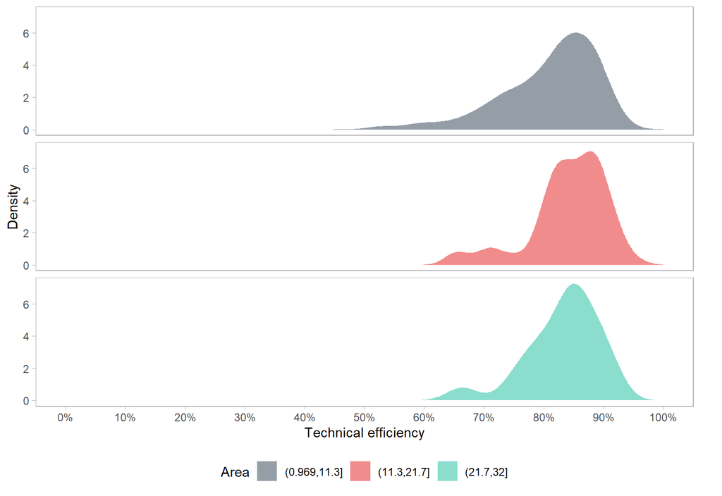

```r
# plotting the density distribution of TE across area interval
data_CDeff %>%
   mutate(area = cut(area, 3)) %>%
   group_by(area) %>%
   ggplot(aes(x = efficiency, fill = area)) +
   geom_density(alpha = 0.5,
                color = NA) +
   facet_grid(area ~ .) +
   scale_fill_discrete(labels =c("(1-10) rai", "(11-21) rai", "(21-32) rai")) +
   scale_x_continuous(breaks = seq(0, 1.0, 0.1), limits = c(0, 1.0),
                      labels =percent_format(accuracy = 1)) +
   theme_light() +
   theme(panel.grid = element_blank(),
         strip.background.y = element_blank(),
         legend.position = "bottom") +
   tidyquant::scale_fill_tq() +
   labs(x = "Technical efficiency",
        y = "Density",
        fill = "Area")
```

### Efficiency distribution from Translog model

```r
# Extracting efficiency score and binding to data set
data_transeff <- cbind(data_scale, as.data.frame(efficiencies(translog_sfa)))

# Calculating efficiency distribution across area interval
data_transeff %>%
   mutate(area = cut(area, 3)) %>%
   group_by(area) %>%
   summarise(mean_TE = mean(efficiency, na.rm = T) * 100 ,
             min_TE = min(efficiency) * 100,
             max_TE  = max(efficiency) * 100,
             # calculating upper-lower bounds with 95% CI (2.26 critical value)
             lower_bound = (mean(efficiency) - 2.66 * sum(abs(diff(efficiency)))
                            / length(efficiency)) * 100,
             upper_bound = (mean(efficiency) + 2.66 * sum(abs(diff(efficiency)))
                            / length(efficiency)) * 100,
             range = (upper_bound - lower_bound)
             ) %>%
   rename("Mean" = mean_TE,
          "Min" = min_TE,
          "Max" = max_TE,
          "Lower bound" = lower_bound,
          "Upper bound" = upper_bound,
          "Range" = range) %>%
   pivot_longer(cols = "Mean":Range, names_to = "TE") %>%
   pivot_wider(names_from = area) %>%
   rename("(1-10)" = '(0.969,11.3]',
          "(11-20)" = '(11.3,21.7]',
          "(21-23)" = '(21.7,32]') %>%
   kable(digits = 2,
         caption = "Mean technical efficiency score
         and its range from Translog model") %>%
   kable_classic_2() %>%
   kable_styling(full_width = F,
                 bootstrap_options = c("striped", "hover",
                                       "condensed", "responsive"))
```

Mean technical efficiency score and its range from Translog model

| TE | (1-10) | (11-20) | (21-23) |
| --- | --- | --- | --- |
| Mean | 82.05 | 84.82 | 83.35 |
| Min | 55.42 | 66.25 | 66.62 |
| Max | 93.78 | 95.66 | 91.12 |
| Lower bound | 61.73 | 69.26 | 68.47 |
| Upper bound | 102.37 | 100.39 | 98.22 |
| Range | 40.64 | 31.14 | 29.75 |

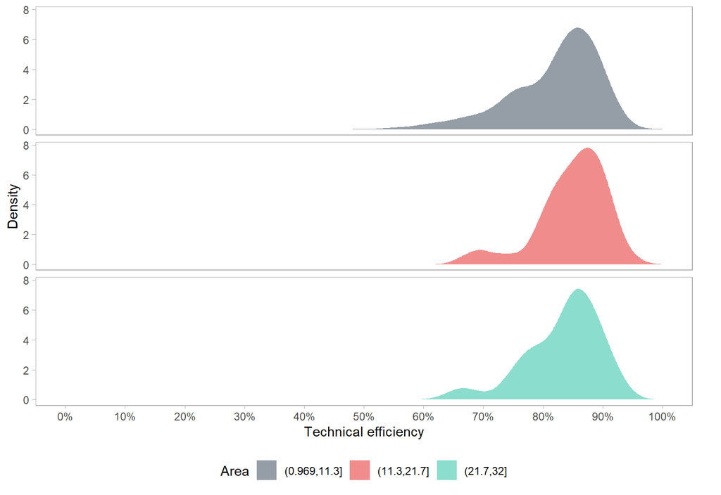

```r
# plotting the density distribution of TE across area interval
data_transeff %>%
   mutate(area = cut(area, 3)) %>%
   group_by(area) %>%
   ggplot(aes(x = efficiency, fill = area)) +
   geom_density(alpha = 0.5,
                color = NA) +
   facet_grid(area ~ .) +
   scale_fill_discrete(labels =c("(1-10) rai", "(11-21) rai", "(21-32) rai")) +
   scale_x_continuous(breaks = seq(0, 1.0, 0.1), limits = c(0, 1.0),
                      labels =percent_format(accuracy = 1)) +
   theme_light() +
   theme(panel.grid = element_blank(),
         strip.background.y = element_blank(),
         legend.position = "bottom") +
   tidyquant::scale_fill_tq() +
   labs(x = "Technical efficiency",
        y = "Density",
        fill = "Area")
```

# 5 Test of assumptions using likelihood ratio test

The LR test is performed using the `lmtest` package. The test compare the fit of one model to the fit of the other. Here, the LR test was used to test the null hypotheses of the study on model choice and hypotheses.

$$LR = 2(loglik(model2) - loglik(model1))$$

## 5.1 Test on the functional form

### OLS vs Cobb Douglas model

```r
# OLS vs Cobb-Douglas
lrtest(cd_sfa) %>%
   kable(digits = 2) %>%
   kable_classic(full_width = F)
```

| #Df | LogLik | Df | Chisq | Pr(>Chisq) |
| --- | --- | --- | --- | --- |
| 9 | -21.39 | NA | NA | NA |
| 10 | -19.85 | 1 | 3.07 | 0.04 |

> Decision: Reject Null: OLS model; Accept alternative: Cobb-Douglas model at alpha 0.05.

### OLS vs Translog

```r
# OLS vs Translog
lrtest(translog_sfa) %>%
   kable(digits = 2) %>%
   kable_classic(full_width = F)
```

| #Df | LogLik | Df | Chisq | Pr(>Chisq) |
| --- | --- | --- | --- | --- |
| 19 | -15.07 | NA | NA | NA |
| 20 | -14.10 | 1 | 1.93 | 0.08 |

> Decision: Accept Null: OLS model at alpha 0.05; Accept alternative: Translog at alpha 0.10.

### Cobb-Douglas vs Translog

```r
# Cobb-Douglas vs Translog
lrtest(cd_sfa, translog_sfa) %>%
   kable(digits = 2) %>%
   kable_classic(full_width = F)
```

| #Df | LogLik | Df | Chisq | Pr(>Chisq) |
| --- | --- | --- | --- | --- |
| 10 | -19.85 | NA | NA | NA |
| 20 | -14.10 | 10 | 11.5 | 0.32 |

> Decision: Accept Null: Cobb-Douglas Model.

## 5.2 Test on the inefficiency distribution

### Cobb-Douglas Model: Half-normal vs Truncated

```r
# estimating truncated CD SFA
cd_sfa_trunc <- sfa(log(prod) ~ log(seed.q) + log(fert.q) + log(fl.labor.hr) +
                 log(hl.labor.hr) + pestq.dum,
                 data = data_scale,
                 truncNorm = TRUE)

# Half-normal vs Truncated
lrtest(cd_sfa, cd_sfa_trunc) %>%
   kable(digits = 2) %>%
   kable_classic(full_width = F)
```

| #Df | LogLik | Df | Chisq | Pr(>Chisq) |
| --- | --- | --- | --- | --- |
| 10 | -19.85 | NA | NA | NA |
| 9 | -19.77 | -1 | 0.17 | 0.68 |

### Translog Model: Half-normal vs Truncated

```r
# estimating truncated translog SFA
translog_sfa_trunc <- sfa(log(prod) ~ log(seed.q) + log(fert.q) + log(fl.labor.hr)
   + log(hl.labor.hr) + I(0.5 * log(seed.q)^2) + I(0.5 * log(fert.q)^2)
   + I(0.5 * log(fl.labor.hr)^2) + I(0.5 * log(hl.labor.hr)^2)
   + I(log(seed.q) * log(fert.q)) + I(log(seed.q) * log(fl.labor.hr))
   + I(log(seed.q) * log(hl.labor.hr)) + I(log(fert.q) * log(fl.labor.hr))
   + I(log(fert.q) * log(hl.labor.hr)) + I(log(fl.labor.hr) * log(hl.labor.hr)),
   data = data_scale, truncNorm = TRUE)

# Half-normal vs Truncated
lrtest(translog_sfa, translog_sfa_trunc) %>%
   kable(digits = 2) %>%
   kable_classic(full_width = F)
```

| #Df | LogLik | Df | Chisq | Pr(>Chisq) |
| --- | --- | --- | --- | --- |
| 20 | -14.10 | NA | NA | NA |
| 18 | -17.92 | -2 | 7.63 | 0.02 |

# 6 Input elasticity and return to scale

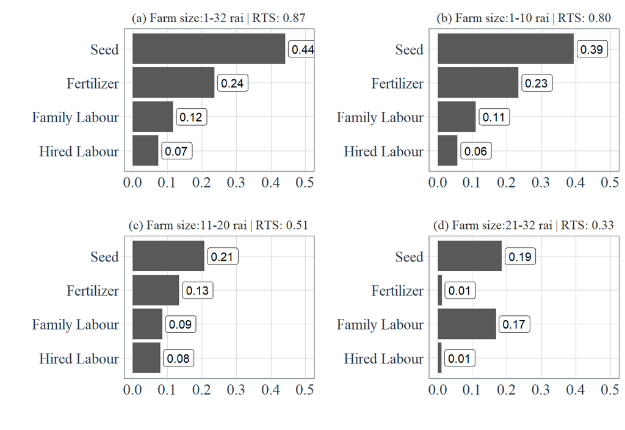

```r
# reorder factor input by estimate
# allow bar to sort by estimate value
cd_ie$input <- fct_reorder(cd_ie$input, cd_ie$estimate)

# bar graph for the elasticity coefficient
cd_ie %>% ggplot(aes(x = input, y = abs(estimate))) +
   geom_col(position = "dodge") +
   scale_y_continuous(breaks = seq(0.0, 0.5, 0.1), limits = c(0, 0.5)) +
   coord_flip() +
   geom_label(aes(label = abs(estimate) %>% round(2)), hjust = -0.1) +
   facet_wrap(~area, scales = "free") +
   tidyquant::theme_tq() +
   theme(#panel.grid.minor.x = element_blank(),
         #panel.grid.major.x = element_line(linetype = "dashed"),
         #panel.grid.major.y = element_blank(),
         strip.text.x = element_text(color = "grey20",
                                     size = 12),
         #strip.background = element_rect(fill = "grey20"),
         strip.background = element_blank(),
         text = element_text(family = "Times New Roman"),
         axis.text = element_text(size = 14)) +
   labs(x = "\n ",
        y = "\n ")
```

> Note: Pesticide and machine input were used as control variables as they are coded as dummy variables. A significant missing values were observed on pesticides and machine input.

# 7 Effects of Z variables and collective action activities

$$U_i = \theta_0 + \sum_{n=1}^8 \theta_n Z_{ni} + \sum_{p=1}^8 \beta_p CA_{pi}$$

### Collective action effects: Overall

```r
# Cobb-Douglas SFA with z variables and collective action variables
cd_sfa_z <- sfa(log(prod) ~ log(seed.q) + log(fert.q) + log(fl.labor.hr)
    + log(hl.labor.hr) + pestq.dum + soil_qual + topog |
    + age + hh.mem + educ_primary + educ_secondary + yrs.farming  + off_farm
    + sell_market + input_market
    + maintain_1 + maintain_3
    + meeting_1 + meeting_3
    + dispute_1 + dispute_3
    + policy_1 + policy_3,
    data = data_scale)


#summary results
cd_sfa_z %>% summary(extraPar = T)
```

```
Efficiency Effects Frontier (see Battese & Coelli 1995)
Inefficiency decreases the endogenous variable (as in a production function)
The dependent variable is logged
Iterative ML estimation terminated after 37 iterations:
log likelihood values and parameters of two successive iterations
are within the tolerance limit

final maximum likelihood estimates
                    Estimate  Std. Error z value  Pr(>|z|)
(Intercept)       1.6407e-01  5.8325e-02  2.8131  0.004907 **
log(seed.q)       4.2783e-01  4.1202e-02 10.3837 < 2.2e-16 ***
log(fert.q)       2.3644e-01  3.6055e-02  6.5577 5.464e-11 ***
log(fl.labor.hr)  1.1246e-01  1.8255e-02  6.1606 7.248e-10 ***
log(hl.labor.hr)  8.3978e-02  1.7689e-02  4.7475 2.060e-06 ***
pestq.dum        -8.3702e-02  3.1566e-02 -2.6516  0.008010 **
soil_qual        -2.9725e-02  5.2299e-02 -0.5684  0.569786
topog             2.5356e-02  3.5622e-02  0.7118  0.476586
Z_(Intercept)    -1.7239e-01  2.9582e-01 -0.5827  0.560063
Z_age             2.4456e-03  4.5469e-03  0.5379  0.590677
Z_hh.mem         -3.2587e-02  2.9879e-02 -1.0906  0.275433
Z_educ_primary   -4.3864e-01  1.4238e-01 -3.0809  0.002064 **
Z_educ_secondary -6.8191e-01  1.5128e-01 -4.5075 6.561e-06 ***
Z_yrs.farming     8.7320e-03  3.6195e-03  2.4125  0.015846 *
Z_off_farm       -2.7746e-01  1.1294e-01 -2.4566  0.014025 *
Z_sell_market    -1.2596e-02  6.7665e-03 -1.8616  0.062664 .
Z_input_market   -2.3517e-02  9.0397e-03 -2.6016  0.009280 **
Z_maintain_1      3.5764e-01  2.0134e-01  1.7763  0.075680 .
Z_maintain_3      3.2398e-01  1.4657e-01  2.2104  0.027078 *
Z_meeting_1       1.2461e-02  2.1668e-01  0.0575  0.954142
Z_meeting_3       2.0280e-01  1.2230e-01  1.6582  0.097271 .
Z_dispute_1       3.9752e-02  1.0905e-01  0.3645  0.715459
Z_dispute_3      -1.4226e-01  1.0261e-01 -1.3864  0.165611
Z_policy_1       -9.5924e-01  2.3160e-01 -4.1418 3.446e-05 ***
Z_policy_3        1.0936e-01  1.0374e-01  1.0541  0.291815
sigmaSq           6.1493e-02  6.2370e-03  9.8594 < 2.2e-16 ***
gamma             1.0000e-08  3.9103e-09  2.5573  0.010548 *
sigmaSqU          6.1493e-10  2.6162e-10  2.3505  0.018748 *
sigmaSqV          6.1493e-02  6.2370e-03  9.8594 < 2.2e-16 ***
sigma             2.4798e-01  1.2576e-02 19.7187 < 2.2e-16 ***
sigmaU            2.4798e-05  5.2750e-06  4.7010 2.589e-06 ***
sigmaV            2.4798e-01  1.2576e-02 19.7187 < 2.2e-16 ***
lambdaSq          1.0000e-08  3.9103e-09  2.5573  0.010548 *
lambda            1.0000e-04  1.9552e-05  5.1147 3.143e-07 ***
---
Signif. codes:  0 '***' 0.001 '**' 0.01 '*' 0.05 '.' 0.1 ' ' 1
log likelihood value: -5.006093

cross-sectional data
total number of observations = 294

mean efficiency: 0.9702226
```

### Collective action effects: irrigation maintenance

```r
sfa_z_maintain <- sfa(log(prod) ~ log(seed.q) + log(fert.q) + log(fl.labor.hr)
    + log(hl.labor.hr) + pestq.dum + soil_qual + topog |
    + age + educ_primary + educ_secondary + hh.mem + off_farm
    + input_market + sell_market + yrs.farming
    + M55_scale - 1, data = data_scale)

sfa_z_maintain %>% summary(extraPar = TRUE)
```

```
Efficiency Effects Frontier (see Battese & Coelli 1995)
Inefficiency decreases the endogenous variable (as in a production function)
The dependent variable is logged
Iterative ML estimation terminated after 31 iterations:
log likelihood values and parameters of two successive iterations
are within the tolerance limit

final maximum likelihood estimates
                   Estimate Std. Error z value  Pr(>|z|)
(Intercept)       0.3423516  0.0854384  4.0070 6.149e-05 ***
log(seed.q)       0.4473977  0.0392243 11.4061 < 2.2e-16 ***
log(fert.q)       0.2246296  0.0358646  6.2633 3.770e-10 ***
log(fl.labor.hr)  0.1113655  0.0183452  6.0705 1.275e-09 ***
log(hl.labor.hr)  0.0752951  0.0176335  4.2700 1.955e-05 ***
pestq.dum        -0.0730187  0.0308672 -2.3656 0.0180019 *
soil_qual        -0.0737889  0.0502647 -1.4680 0.1421025
topog             0.0178926  0.0354104  0.5053 0.6133533
Z_age            -0.0037750  0.0062414 -0.6048 0.5452904
Z_educ_primary   -0.3345887  0.1851581 -1.8070 0.0707556 .
Z_educ_secondary -0.4126683  0.2174128 -1.8981 0.0576847 .
Z_hh.mem         -0.0266903  0.0302918 -0.8811 0.3782609
Z_off_farm       -0.1752826  0.1578015 -1.1108 0.2666634
Z_input_market    0.0039420  0.0073792  0.5342 0.5931989
Z_sell_market    -0.0017277  0.0080487 -0.2147 0.8300336
Z_yrs.farming     0.0096362  0.0064527  1.4934 0.1353448
Z_M55_scale       0.3229769  0.1517128  2.1289 0.0332650 *
sigmaSq           0.0963582  0.0366192  2.6314 0.0085044 **
gamma             0.5221223  0.2887610  1.8081 0.0705837 .
sigmaSqU          0.0503108  0.0461178  1.0909 0.2753093
sigmaSqV          0.0460474  0.0133037  3.4612 0.0005377 ***
sigma             0.3104161  0.0589840  5.2627 1.419e-07 ***
sigmaU            0.2243006  0.1028037  2.1818 0.0291217 *
sigmaV            0.2145866  0.0309985  6.9225 4.438e-12 ***
lambdaSq          1.0925857  1.2644600  0.8641 0.3875478
lambda            1.0452682  0.6048495  1.7281 0.0839621 .
---
Signif. codes:  0 '***' 0.001 '**' 0.01 '*' 0.05 '.' 0.1 ' ' 1
log likelihood value: -10.62726

cross-sectional data
total number of observations = 294

mean efficiency: 0.847915
```

### Collective action effects: Group meeting

```r
sfa_z_meeting <- sfa(log(prod) ~ log(seed.q) + log(fert.q) + log(fl.labor.hr)
    + log(hl.labor.hr) + pestq.dum + soil_qual + topog |
    + age + educ_primary + educ_secondary + hh.mem + off_farm
    + input_market + sell_market + yrs.farming
    + L41 - 1, data = data_scale)

sfa_z_meeting %>% summary(extraPar = TRUE)
```

```
Efficiency Effects Frontier (see Battese & Coelli 1995)
Inefficiency decreases the endogenous variable (as in a production function)
The dependent variable is logged
Iterative ML estimation terminated after 61 iterations:
log likelihood values and parameters of two successive iterations
are within the tolerance limit

final maximum likelihood estimates
                    Estimate  Std. Error  z value  Pr(>|z|)
(Intercept)       2.2255e-01  5.7178e-02   3.8923 9.930e-05 ***
log(seed.q)       4.4558e-01  3.8723e-02  11.5068 < 2.2e-16 ***
log(fert.q)       2.2797e-01  3.3895e-02   6.7257 1.747e-11 ***
log(fl.labor.hr)  1.1607e-01  1.8520e-02   6.2673 3.673e-10 ***
log(hl.labor.hr)  7.7895e-02  1.7509e-02   4.4489 8.631e-06 ***
pestq.dum        -7.0483e-02  2.9881e-02  -2.3588  0.018336 *
soil_qual        -7.0428e-02  4.9159e-02  -1.4327  0.151953
topog             2.0172e-02  3.5058e-02   0.5754  0.565039
Z_age            -6.3763e-04  1.9795e-03  -0.3221  0.747361
Z_educ_primary   -2.8410e-01  9.4323e-02  -3.0120  0.002596 **
Z_educ_secondary -2.8446e-01  8.9085e-02  -3.1931  0.001407 **
Z_hh.mem         -1.6123e-02  1.0343e-02  -1.5588  0.119039
Z_off_farm       -1.1163e-01  5.7685e-02  -1.9351  0.052973 .
Z_input_market    3.7038e-03  2.7364e-03   1.3535  0.175888
Z_sell_market    -3.9048e-03  2.8928e-03  -1.3499  0.177059
Z_yrs.farming     6.1721e-03  2.3739e-03   2.5999  0.009324 **
Z_L41             4.3492e-02  1.4042e-02   3.0973  0.001953 **
sigmaSq           6.2236e-02  4.9432e-03  12.5903 < 2.2e-16 ***
gamma             5.4934e-04  1.5615e-06 351.8088 < 2.2e-16 ***
sigmaSqU          3.4189e-05  2.7179e-06  12.5790 < 2.2e-16 ***
sigmaSqV          6.2202e-02  4.9405e-03  12.5903 < 2.2e-16 ***
sigma             2.4947e-01  9.9073e-03  25.1806 < 2.2e-16 ***
sigmaU            5.8471e-03  2.3242e-04  25.1580 < 2.2e-16 ***
sigmaV            2.4940e-01  9.9046e-03  25.1807 < 2.2e-16 ***
lambdaSq          5.4964e-04  1.5632e-06 351.6155 < 2.2e-16 ***
lambda            2.3444e-02  3.3338e-05 703.2310 < 2.2e-16 ***
---
Signif. codes:  0 '***' 0.001 '**' 0.01 '*' 0.05 '.' 0.1 ' ' 1
log likelihood value: -9.018398

cross-sectional data
total number of observations = 294

mean efficiency: 0.9484335
```

### Collective action effects: Conflich resolution

```r
sfa_z_conflict <- sfa(log(prod) ~ log(seed.q) + log(fert.q) + log(fl.labor.hr)
    + log(hl.labor.hr) + pestq.dum + soil_qual + topog |
    + age + educ_primary + educ_secondary + hh.mem + off_farm
    + input_market + sell_market + yrs.farming
    + N75_scale - 1, data = data_scale)


sfa_z_conflict %>% summary(extraPar = TRUE)
```

```
Efficiency Effects Frontier (see Battese & Coelli 1995)
Inefficiency decreases the endogenous variable (as in a production function)
The dependent variable is logged
Iterative ML estimation terminated after 33 iterations:
log likelihood values and parameters of two successive iterations
are within the tolerance limit

final maximum likelihood estimates
                   Estimate Std. Error z value  Pr(>|z|)
(Intercept)       0.3402693  0.0741043  4.5918 4.395e-06 ***
log(seed.q)       0.4636832  0.0396363 11.6984 < 2.2e-16 ***
log(fert.q)       0.2166412  0.0345346  6.2732 3.538e-10 ***
log(fl.labor.hr)  0.1127427  0.0184370  6.1150 9.654e-10 ***
log(hl.labor.hr)  0.0735303  0.0179214  4.1029 4.080e-05 ***
pestq.dum        -0.0770526  0.0300267 -2.5661 0.0102838 *
soil_qual        -0.0710012  0.0508977 -1.3950 0.1630222
topog             0.0206144  0.0355503  0.5799 0.5620056
Z_age            -0.0040284  0.0086281 -0.4669 0.6405741
Z_educ_primary   -0.4470165  0.2658745 -1.6813 0.0927034 .
Z_educ_secondary -0.4967317  0.2882363 -1.7233 0.0848254 .
Z_hh.mem         -0.0122947  0.0298269 -0.4122 0.6801915
Z_off_farm       -0.2474016  0.2230008 -1.1094 0.2672490
Z_input_market    0.0070634  0.0090532  0.7802 0.4352656
Z_sell_market    -0.0019635  0.0100001 -0.1964 0.8443357
Z_yrs.farming     0.0116942  0.0097003  1.2056 0.2279895
Z_N75_scale       0.1707453  0.1091244  1.5647 0.1176567
sigmaSq           0.1222162  0.0517573  2.3613 0.0182095 *
gamma             0.6346958  0.1917814  3.3095 0.0009347 ***
sigmaSqU          0.0775701  0.0551885  1.4055 0.1598581
sigmaSqV          0.0446461  0.0095470  4.6765 2.919e-06 ***
sigma             0.3495943  0.0740249  4.7227 2.328e-06 ***
sigmaU            0.2785141  0.0990766  2.8111 0.0049373 **
sigmaV            0.2112962  0.0225914  9.3529 < 2.2e-16 ***
lambdaSq          1.7374444  1.4371332  1.2090 0.2266761
lambda            1.3181216  0.5451444  2.4179 0.0156090 *
---
Signif. codes:  0 '***' 0.001 '**' 0.01 '*' 0.05 '.' 0.1 ' ' 1
log likelihood value: -12.74509

cross-sectional data
total number of observations = 294

mean efficiency: 0.848938
```

### Collective action effects: Policy adherence

```r
sfa_z_policy <- sfa(log(prod) ~ log(seed.q) + log(fert.q) + log(fl.labor.hr)
    + log(hl.labor.hr) + pestq.dum + soil_qual + topog |
    + age + educ_primary + educ_secondary + hh.mem + off_farm
    + input_market + sell_market + yrs.farming
    + M54_scale, data = data_scale)



sfa_z_policy %>% summary(extraPar = TRUE)
```

```
Efficiency Effects Frontier (see Battese & Coelli 1995)
Inefficiency decreases the endogenous variable (as in a production function)
The dependent variable is logged
Iterative ML estimation terminated after 34 iterations:
log likelihood values and parameters of two successive iterations
are within the tolerance limit

final maximum likelihood estimates
                    Estimate  Std. Error z value  Pr(>|z|)
(Intercept)       2.6137e-01  5.9303e-02  4.4074 1.046e-05 ***
log(seed.q)       4.2188e-01  4.0720e-02 10.3603 < 2.2e-16 ***
log(fert.q)       2.5055e-01  3.5040e-02  7.1505 8.647e-13 ***
log(fl.labor.hr)  1.1614e-01  1.8532e-02  6.2670 3.681e-10 ***
log(hl.labor.hr)  8.2296e-02  1.7809e-02  4.6209 3.820e-06 ***
pestq.dum        -7.6134e-02  3.0953e-02 -2.4597  0.013907 *
soil_qual        -9.9569e-02  5.1232e-02 -1.9435  0.051954 .
topog             1.6891e-02  3.6812e-02  0.4588  0.646353
Z_(Intercept)     9.2990e-02  2.7791e-01  0.3346  0.737925
Z_age            -3.2679e-03  4.8402e-03 -0.6752  0.499567
Z_educ_primary   -2.0433e-01  1.4797e-01 -1.3809  0.167318
Z_educ_secondary -2.6022e-01  1.4248e-01 -1.8264  0.067795 .
Z_hh.mem         -1.9066e-02  2.6162e-02 -0.7288  0.466135
Z_off_farm       -3.4407e-01  1.0987e-01 -3.1315  0.001739 **
Z_input_market    1.5504e-03  6.6025e-03  0.2348  0.814352
Z_sell_market    -1.0501e-02  6.4567e-03 -1.6264  0.103870
Z_yrs.farming     5.5380e-03  3.2717e-03  1.6927  0.090511 .
Z_M54_scale       3.1349e-01  1.5109e-01  2.0748  0.038005 *
sigmaSq           5.8553e-02  6.0111e-03  9.7408 < 2.2e-16 ***
gamma             1.0002e-08  4.4802e-06  0.0022  0.998219
sigmaSqU          5.8566e-10  2.6233e-07  0.0022  0.998219
sigmaSqV          5.8553e-02  6.0111e-03  9.7408 < 2.2e-16 ***
sigma             2.4198e-01  1.2421e-02 19.4815 < 2.2e-16 ***
sigmaU            2.4200e-05  5.4199e-03  0.0045  0.996437
sigmaV            2.4198e-01  1.2421e-02 19.4815 < 2.2e-16 ***
lambdaSq          1.0002e-08  4.4802e-06  0.0022  0.998219
lambda            1.0001e-04  2.2398e-02  0.0045  0.996437
---
Signif. codes:  0 '***' 0.001 '**' 0.01 '*' 0.05 '.' 0.1 ' ' 1
log likelihood value: -8.938842

cross-sectional data
total number of observations = 294

mean efficiency: 0.9461003
```

# 8 Additional plots

### Collective action activities

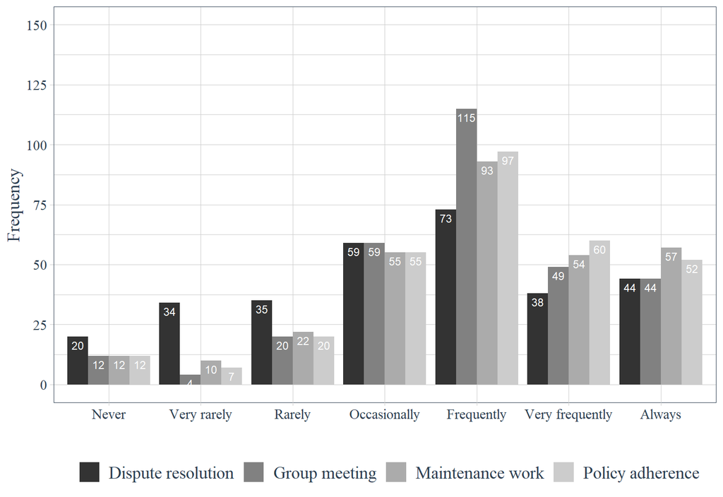

```r
data_likert %>% ggplot(aes(x = response, y = frequency, fill = activity)) +
   geom_col(position = "dodge") +
   tidyquant::theme_tq() +
   scale_fill_grey() +
   scale_y_continuous(limits = c(0, 150), breaks = seq(0, 150, 25)) +
   geom_text(aes(label = frequency), vjust = 1.5, color = "white",
             position = position_dodge(0.9), size = 3) +
   theme(legend.title = element_blank(),
         legend.text = element_text(size = 14),
         legend.position = "bottom",
         text = element_text(size = 14, family = "Times New Roman")) +
   labs(fill = "",
        x = "",
        y = "Frequency")
```

### Efficiency distribution across collective activities

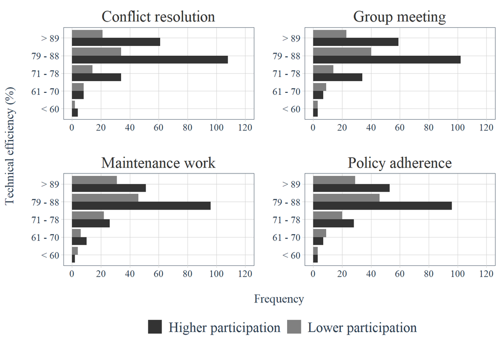

```r
data_eff %>%
   mutate(eff_int = cut(efficiency, 5, include.lowest = T)) %>%
   group_by(ca, value, eff_int) %>%
   summarise(frequency = n()) %>%
   ungroup() %>%
   mutate(eff_int = recode(eff_int,
                           '[0.526,0.613]' = "< 60",
                           '(0.613,0.699]' = "61 - 70",
                           '(0.699,0.785]' = "71 - 78",
                           '(0.785,0.872]' = "79 - 88",
                           '(0.872,0.958]' = "> 89")) %>%
   ggplot(aes(x = eff_int, y = frequency, fill = value)) +
   geom_col(position = "dodge") +
   facet_wrap(~ ca, scales = "free") +
   coord_flip() +
   tidyquant::theme_tq() +
   scale_fill_grey(start = 0.2, end = 0.5,
                   labels = c("Higher participation", "Lower participation")) +
   scale_y_continuous(breaks = seq(0, 120,  20), limits = c(0, 120)) +
   theme(#strip.background = element_rect(fill = "grey20"),
         strip.background = element_blank(),
         strip.text.x = element_text(size = 18, color = "grey20"),
         legend.title = element_blank(),
         legend.position = "bottom",
         legend.text = element_text(size = 16),
         text = element_text(size = 14, family = "Times New Roman")) +
   labs(x  = "Technical efficiency (%)\n",
        y = "\nFrequency")
```